# Mixed Effects activity in R, based on Brown (2021)

Jamil Palacios Bhanji - Statistical Methods

2024-04-10

Today’s activity is based entirely on [Violet Brown’s 2021 article, “An Introduction to Linear Mixed-Effects Modeling in R.” Advances in Methods and Practices in Psychological Science, 4(1), pp. 1–19.](https://doi.org/10.1177%2F2515245920960351)

## Goals for today

- Learn differences between a linear mixed effects model approach and a standard linear model approach with aggregated data for repeated measures in a crossed design
- Learn about fixed and random effects and how to specify them in a formula using the `lme4::lmer()` function in R
- Learn how to address problems in model fitting (failure to converge, or singular fit)
- Learn how to interpret output from a linear mixed effects model
- Use model comparison for significance tests (for full model compared to null model, for individual terms in a model)

### Step 0

- install the required packages:
  - `install.packages("optimx")` *note: some versions of R may make it tricky to install this package - it is only needed for one step so you can skip it if needed
  - `lme4` you should already have installed
  - `afex` you should already have installed
- setup your project folder (with data and r_docs folders within) and start a new project in this existing folder
- start a new R markdown for your code and notes and include the usual code in the setup chunk, but add `library(lme4)` to the setup chunk (and then run the chunk)
  - Older versions of R may give an error along the lines of `cholmod_factor_ldetA not provided by package Matrix` when you try to load the package. If this happens, try running these two lines of code in your console (why? see [this discussion](https://stackoverflow.com/questions/77481539/error-in-initializeptr-function-cholmod-factor-ldeta-not-provided-by-pack))  
    `oo <- options(repos = "https://cran.r-project.org/")`  
    `install.packages("Matrix")`  
    `install.packages("lme4")`  
    `options(oo)`
- Download these files and place in the data folder within your project folder:
  - rt_dummy_data.csv for example 1

## Example 1: trial level analysis of a within-subject (2 level) effect

### Step 1 - import the first data file and check it out

Variables:  
- **Dependent variable:** `RT`=response time (ms) for the secondary task  
- **Independent variable:** `modality`=listening condition (“Audio-only” or “Audiovisual”)  
- `stim`=word stimulus for each trial  
- `PID`=participant identifier

#### What to do:

1. Use the `read_csv()` function to import the `rt_dummy_data.csv` file and store it in a variable named `rt_data`. There are no missing data that you need to deal with, because trials with a missed response are not included in the data file. **Store the `modality` variable as a factor.**

```r
#import the data
rt_data <- readr::read_csv(
  "data/rt_dummy_data.csv", show_col_types = FALSE) |>
  mutate(
    modality = forcats::as_factor(modality)
  )
```

2. Use the `group_by()` and `summarise()` functions to compute the following and print it to the screen - **notice that you are ignoring the `PID` when computing these values** (not something you would normally do but we do it here to aid learning):
   - mean RT across all trials in each modality condition
   - median RT across all trials in each modality condition
   - standard devation of RT across all trials in each modality condition

```r
#descriptives across trials (ignoring participant ID)
rt_data |> dplyr::group_by(modality) |> dplyr::summarise(
  totalN = n(),
  trialwiseRTmean = mean(RT, na.rm = TRUE),
  trialwiseRTmedian = median(RT, na.rm = TRUE),
  trialwiseRTsd = sd(RT, na.rm = TRUE)
) |> ungroup() |>
  kableExtra::kbl(
    caption = "descriptives by modality condition (trialwise, PID ignored)",
    digits = 2) |>
  kableExtra::kable_classic(full_width=FALSE)
```

descriptives by modality condition (trialwise, PID ignored)

| modality | totalN | trialwiseRTmean | trialwiseRTmedian | trialwiseRTsd |
| --- | --- | --- | --- | --- |
| Audio-only | 10647 | 1041.46 | 1013 | 302.42 |
| Audiovisual | 11032 | 1124.52 | 1100 | 316.56 |

3. Now, first aggregate the data by participant (calculate the number of trials each participant did of each condition, and the mean RT for each condition for each subject) and then print out:
   - mean number of trials in each condition for a participant
   - min and max number of trials in each condition for a participant
   - mean RT across participants (different than before bc you are first aggregating by participant)
   - standard deviation of RT across participants

```r
#first, calc num trials and mean RT for each participant (by condition)
rt_bysub <- rt_data |> dplyr::group_by(modality,PID) |> dplyr::summarise(
  bysub_N = n(),
  bysub_RT = mean(RT),
  bysub_medRT = median(RT),
) |> ungroup()
# now print descriptives, calculated by first aggregating by subject
rt_bysub |> dplyr::group_by(modality) |> dplyr::summarise(
  bysub_mean_N = mean(bysub_N),
  bysub_min_N = min(bysub_N),
  bysub_max_N = max(bysub_N),
  bysub_mean_RT = mean(bysub_RT),
  bysub_sd_RT = sd(bysub_RT)
) |> ungroup() |>
  kableExtra::kbl(
    caption = "descriptives, first aggregated by participant",
    digits = 2) |>
  kableExtra::kable_classic(full_width=FALSE)
```

descriptives, first aggregated by participant

| modality | bysub_mean_N | bysub_min_N | bysub_max_N | bysub_mean_RT | bysub_sd_RT |
| --- | --- | --- | --- | --- | --- |
| Audio-only | 200.89 | 141 | 244 | 1044.07 | 169.89 |
| Audiovisual | 208.15 | 132 | 264 | 1127.23 | 177.91 |

4. Now make a histogram and box plot (split by condition) of the trialwise RTs (ignoring `PID`), then do the same for the RTs that were first aggregated by participant.

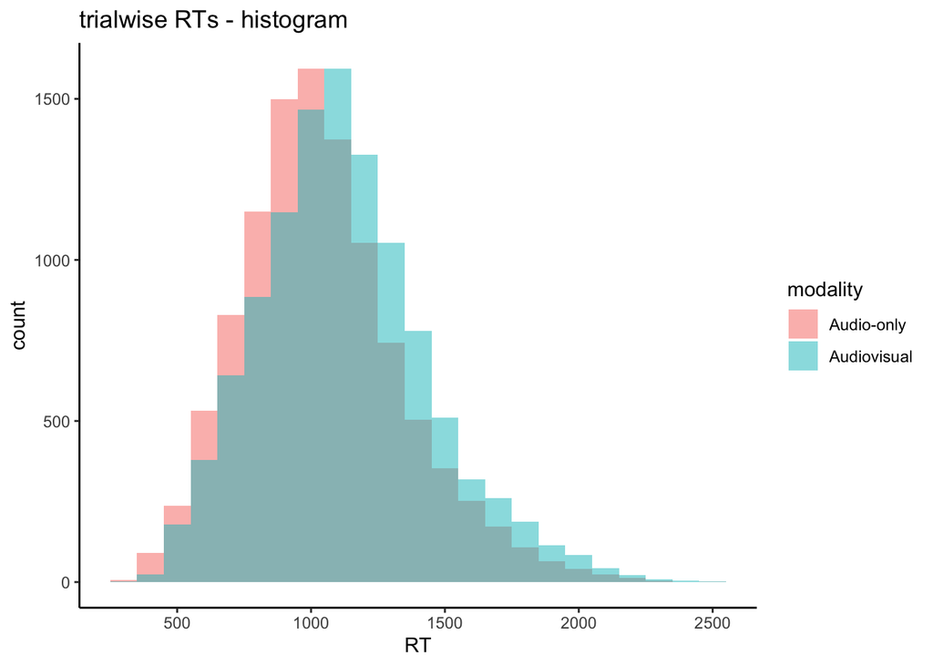

```r
# histogram and box plot of the trialwise data
rt_data |> ggplot( aes(x=RT, fill=modality) ) +
  geom_histogram(position = "identity", alpha = .5, binwidth = 100) +
  theme_classic() + labs(title = "trialwise RTs - histogram")
```

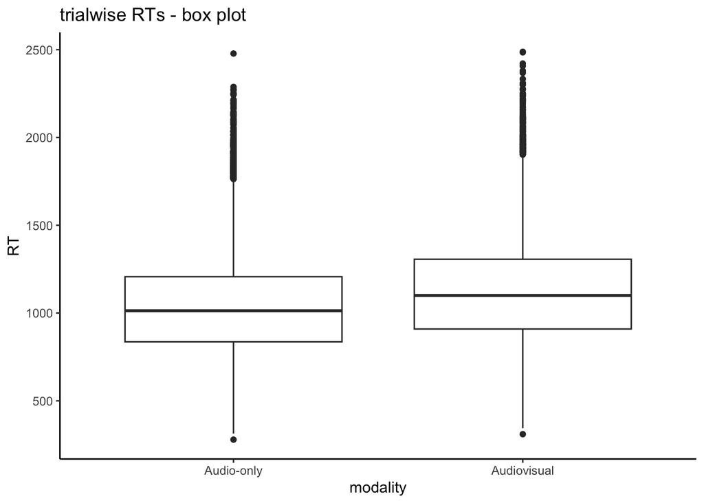

```r
rt_data |> ggplot( aes(x=modality, y=RT) ) +
  geom_boxplot() + theme_classic() + labs(title = "trialwise RTs - box plot")
```

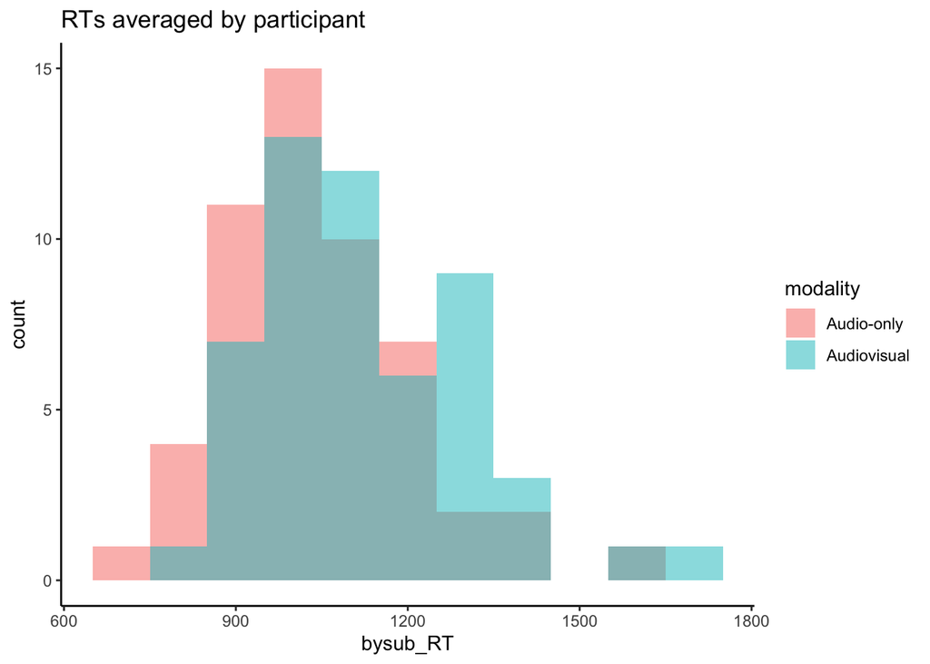

```r
# histogram and box plot of the by participant data
rt_bysub |> ggplot( aes(x=bysub_RT, fill=modality) ) +
  geom_histogram(position = "identity", alpha = .5, binwidth = 100) +
  theme_classic() + labs(title = "RTs averaged by participant")
```

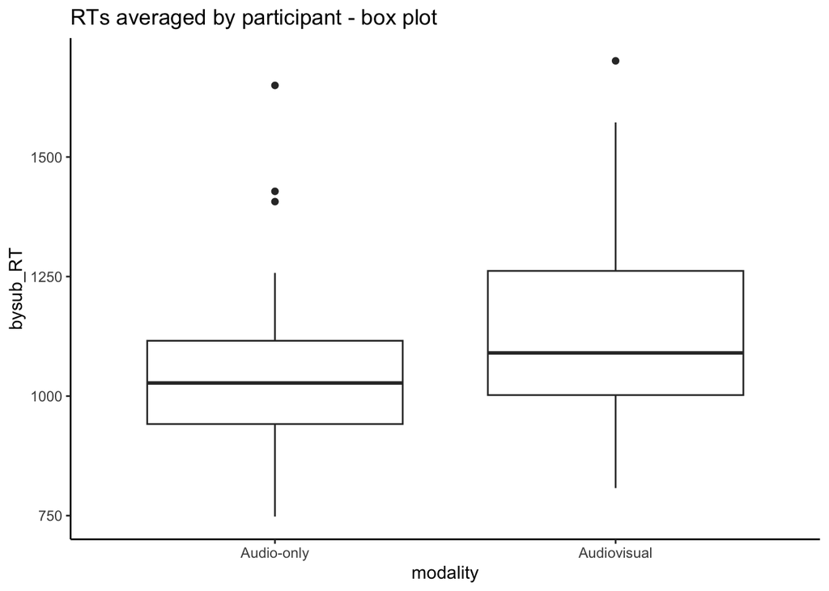

```r
rt_bysub |> ggplot( aes(x=modality, y=bysub_RT) ) +
  geom_boxplot() + theme_classic() + labs(title = "RTs averaged by participant - box plot")
```

- in the trialwise data averaged by condition (ignoring `PID`) you should see that mean RT in the Audio-only condition is 1041 ms and in the Audiovisual condition it is 1125 ms
- in the data that is first averaged by participant and then across participants, the mean RT in the Audio-only condition is 1044 ms and in the Audiovisual condition it is 1127 ms
- the difference in means calculated in the two different ways is due to different numbers of trials for each participant and condition in the trialwise calculation (look at the min and max trial numbers), but in the second calculation each participant’s average RTs are weighted equally. The difference in the two calculations is small here but can be larger in datasets with larger imbalances.
- You should also see that the data are positively skewed (whether we look at trialwise data or aggregated by subject, this is common with RT data) - but we have a sufficient sample size so we aren’t concerned by the non-normal distribution.

### Step 2: Use a traditional method to analyze aggregated RTs (by participant or by item)

#### Step 2.1 - Model the data after aggregating by participant

First, let’s use each participant’s average RT per condition as our unit of analysis. Once we average across trials to get a two values (Audio-only mean RT, Audio-visual mean RT) for each participant, then we can just do a paired t-test on those values like we have done before.  
Try it now, you can use the tibble of RTs averaged by subject and modality that you created in the step above (called `rt_bysub` in the solution code), and pipe it to the `t.test()` function that we’ve used before.

```r
# paired t-test with mean RT per subject in each condition
rt_bysub |> dplyr::arrange(PID) |> t.test(bysub_RT ~ modality, data = _, paired=TRUE)
```

```
##
##  Paired t-test
##
## data:  bysub_RT by modality
## t = -6.6122, df = 52, p-value = 2.055e-08
## alternative hypothesis: true mean difference is not equal to 0
## 95 percent confidence interval:
##  -108.39746  -57.92312
## sample estimates:
## mean difference
##       -83.16029
```

```r
# equivalently, you can run the same test with the lmer function. the formula will make
# more sense after doing the whole activity
rt_bysub_lmer <- rt_bysub |> lme4::lmer(formula = bysub_RT ~ modality + 1 + (1|PID), data = _)
summary(rt_bysub_lmer)
```

```
## Linear mixed model fit by REML ['lmerMod']
## Formula: bysub_RT ~ modality + 1 + (1 | PID)
##    Data: rt_bysub
##
## REML criterion at convergence: 1305.6
##
## Scaled residuals:
##      Min       1Q   Median       3Q      Max
## -2.59477 -0.46495 -0.00148  0.37616  2.64062
##
## Random effects:
##  Groups   Name        Variance Std.Dev.
##  PID      (Intercept) 26066    161.45
##  Residual              4192     64.74
## Number of obs: 106, groups:  PID, 53
##
## Fixed effects:
##                     Estimate Std. Error t value
## (Intercept)          1044.07      23.89  43.697
## modalityAudiovisual    83.16      12.58   6.612
##
## Correlation of Fixed Effects:
##             (Intr)
## modltyAdvsl -0.263
```

- The mean response time in the Audiovisual condition is 83ms slower than in the Audio-only condition. The t-statistic (t(52) = -6.612) and low p-value (.00000002055) show that it is unlikely to observe sample means this different if there is no true difference.
- This is a simple and commonly used approach to analyze data with many trials per condition, where the first step is to average over all trials in a condition for each participant (referred to as *by-participant analysis* in [Judd, Westfall, and Kenny (2012)](https://doi.org/10.1037/a0028347)).
- today we’re going over an alternate approach, linear mixed modeling, where the unit of analysis can be individual trials. Some advantages of this approach are explained in [Brown (2021)](https://doi.org/10.1177%2F2515245920960351) and [Judd, Westfall, and Kenny (2012)](https://doi.org/10.1037/a0028347):
  - captures variance (e.g. trial-to-trial) that may be important for accurately estimating effects of interest
  - allows modeling of multiple random variables (e.g., participants and stimuli), whereas ANOVA approaches allow only one random variable
  - handles unbalanced designs/missed trials
  - handles categorical or continuous predictors, coefficients give magnitude and direction of effects (as opposed to ANOVA approach)
  - extends to other types of outcome variables (e.g., binary)

Next, we will use a linear mixed model approach where trial RTs are the outcome variable, and the model allows for varying intercepts for each participant (e.g. some participants may tend to respond slower overall) and varying intercepts for each word stimulus (e.g., some words may tend to require longer response times) - we refer to these random effects as random intercepts by participant and by stimulus. The model also allows for a varying effect of modality for different subjects and for different stimuli (random slopes by participant and by stimulus).

### Step 3: Linear mixed-effects model of the effect of modality on trial response time

##### Reminder: what are fixed and random effects?

- `modality` is systematically varied so we consider it a fixed effect. In designs (e.g., correlation) where no variable is systematically manipulated we can consider a fixed effect to be one where all levels of interest are covered (e.g., `age` in the lumosity data we used long ago). We expect fixed effects to be consistent across experiments.
- If the levels of a variable are a sample of a larger set we can consider it a random effect (in this activity: participants sampled from a population, and a set of words sampled from a language)
- participants are a sample of a larger population so we consider `PID` a random effect
- word stimuli used in the study are a sample from a language so we consider `stim` a random effect

[Barr et al (2013)](https://doi.org/10.1016/j.jml.2012.11.001) advise using the maximal random effects structure justified by the design. In this case we are justified to include the full random effect structure (random intercepts and slopes for modality, by participant and by stimulus).

#### Full random effect structure

Here is how we include random effects in our formula specification ([see Martin Speekenbrink’s book for a more complete explanation](https://mspeekenbrink.github.io/sdam-r-companion/linear-mixed-effects-models.html#formulating-and-estimating-linear-mixed-effects-models-with-lme4) - screenshot at the bottom of this guide):  
- by-participant varying intercepts: (1|PID)  
- by-stimulus varying intercepts: (1|stim)  
- by-participant varying effect of modality, aka random slope (modality|PID)  
- by-stimulus varying effect of modality, aka random slope (modality|stim)

So let’s specify the model in a typical R formula syntax. Just the fixed effects part would be `RT ~ 1 + modality` to specify that `RT` is the DV and it is predicted by `modality` plus an intercept term. **Remember that `lm()` will automatically dummy code (aka treatment code) a factor variable. The function for linear mixed models, `lmer()`, does the same. So entering `modality` as a predictor is equivalent to a variable where “Audio-only” is set to 0 and “Audiovisual” is set to 1.**

So we start with the formula `RT ~ 1 + modality` - Then we add the by-participant varying intercepts like this: `RT ~ 1 + modality + (1 |PID)`  
- add the by-stimulus varying intercepts: `RT ~ 1 + modality + (1|PID) + (1|stim)`  
- add the by-participant varying effect of modality (random slope by participant): `RT ~ 1 + modality + (1 + modality|PID) + (1|stim)`  
- add the by-stimulus varying effect of modality (random slope by stimulus): `RT ~ 1 + modality + (1 + modality|PID) + (1 + modality|stim)`

#### Step 3.1 - Fit the model

Okay, we have the model formula. We will use the `lme4::lmer()` function to estimate the model - you call it in basically the same way that we have used the `lm()` function before. Pass the data and the formula to the function and store the result in a variable (let’s call it `rt_full_mod`). Then pass that variable to the `summary()` function.

```r
rt_full_mod <- lmer(RT ~ 1 + modality + (1 + modality|PID) +
                      (1 + modality|stim), data = rt_data)
summary(rt_full_mod)
```

```
## Linear mixed model fit by REML ['lmerMod']
## Formula: RT ~ 1 + modality + (1 + modality | PID) + (1 + modality | stim)
##    Data: rt_data
##
## REML criterion at convergence: 302385.7
##
## Scaled residuals:
##     Min      1Q  Median      3Q     Max
## -3.3646 -0.6964 -0.0140  0.5886  5.0003
##
## Random effects:
##  Groups   Name                Variance Std.Dev. Corr
##  stim     (Intercept)           304.0   17.44
##           modalityAudiovisual   216.8   14.73   0.16
##  PID      (Intercept)         28551.1  168.97
##           modalityAudiovisual  7708.7   87.80   -0.17
##  Residual                     65258.9  255.46
## Number of obs: 21679, groups:  stim, 543; PID, 53
##
## Fixed effects:
##                     Estimate Std. Error t value
## (Intercept)          1044.14      23.36  44.706
## modalityAudiovisual    83.18      12.57   6.615
##
## Correlation of Fixed Effects:
##             (Intr)
## modltyAdvsl -0.178
## optimizer (nloptwrap) convergence code: 0 (OK)
## Model failed to converge with max|grad| = 0.00220168 (tol = 0.002, component 1)
```

Did you get a message that the “model failed to converge”? The message means that the algorithm used to estimate the model parameters could not find a good fit within the allotted number of iterations. Although the `summary()` function gives reasonable looking parameters in this case, **you should not report results of a model that failed to converge** - the nonconvergence means the model has not been reliably estimated.

#### What to do when a model does not converge

Here are strategies covered in [Brown (2021)](https://doi.org/10.1177%2F2515245920960351):  
1. Recheck your model and make sure it is not misspecified  
2. Are there major imbalances in the data? (e.g., if one participant or item has very few observations it can cause nonconvergence - consider dropping the participant/item)  
3. Adjust the parameters that control the model fitting process (e.g., change the optimizer method, increase iterations allotted)  
4. Simplify the model by removing correlation between random effects (see [Brown (2021)](https://doi.org/10.1177%2F2515245920960351) p. 10)  
5. Last resort, consider a simpler random effects structure - but document this decision fully, the random effects structure should be theoretically motivated so this is a compromise.

#### Step 3.2 - use afex::all_fit to test different optimizers

*Note: if you were unable to install the “optimx” package then skip to Step 3.3*  
We will try changing the optimizer (strategy 3). First, use the `lme4::allFit()` function (include only the model we fit above as an argument). This function will try several different optimizer algorithms and report warning messages for each. Then you can pick one optimizer that converges and use it. *Note: `lme4::allFit()` replaces the `afex::all_fit()` function that is referred to in [Brown (2021)](https://doi.org/10.1177%2F2515245920960351). Click the button for the code to run the `all_fit()` function and see the output:

```r
allFit(rt_full_mod)
```

```
## bobyqa : [OK]
## Nelder_Mead : [OK]
## nlminbwrap : [OK]
## optimx.L-BFGS-B :
```

```
## Warning in checkConv(attr(opt, "derivs"), opt$par, ctrl = control$checkConv, :
## Model failed to converge with max|grad| = 0.0240828 (tol = 0.002, component 1)
```

```
## [OK]
## nloptwrap.NLOPT_LN_NELDERMEAD : [OK]
## nloptwrap.NLOPT_LN_BOBYQA :
```

```
## [OK]
```

```
## original model:
## RT ~ 1 + modality + (1 + modality | PID) + (1 + modality | stim)
## data:  rt_data
## optimizers (6): bobyqa, Nelder_Mead, nlminbwrap, optimx.L-BFGS-B,nloptwrap.NLOPT_LN_NELDERME...
## differences in negative log-likelihoods:
## max= 0.00015 ; std dev= 6.1e-05
```

#### Step 3.3 - Re-fit the model with a different optimizer

```r
rt_full_mod <- lmer(RT ~ 1 + modality + (1 + modality|PID) + (1 + modality|stim),
                    data = rt_data,
                    control = lmerControl(optimizer = "bobyqa"))
summary(rt_full_mod)
```

```
## Linear mixed model fit by REML ['lmerMod']
## Formula: RT ~ 1 + modality + (1 + modality | PID) + (1 + modality | stim)
##    Data: rt_data
## Control: lmerControl(optimizer = "bobyqa")
##
## REML criterion at convergence: 302385.7
##
## Scaled residuals:
##     Min      1Q  Median      3Q     Max
## -3.3646 -0.6964 -0.0140  0.5886  5.0003
##
## Random effects:
##  Groups   Name                Variance Std.Dev. Corr
##  stim     (Intercept)           303.9   17.43
##           modalityAudiovisual   216.7   14.72   0.16
##  PID      (Intercept)         28552.8  168.98
##           modalityAudiovisual  7709.8   87.81   -0.17
##  Residual                     65258.8  255.46
## Number of obs: 21679, groups:  stim, 543; PID, 53
##
## Fixed effects:
##                     Estimate Std. Error t value
## (Intercept)          1044.14      23.36  44.704
## modalityAudiovisual    83.18      12.58   6.615
##
## Correlation of Fixed Effects:
##             (Intr)
## modltyAdvsl -0.178
```

#### Step 3.4 - hypothesis testing

The first thing you may notice in the output is that there is no p-value for our fixed effect (if you do see a p-value then you probably loaded the `afex` the `lmerTest` package, so you ran a slightly different function). The recommended way to compute a p-value to test a null hypothesis is by comparing a model with the effect of interest to a model that is identical but with the fixed effect of interest removed [(Brown, 2021)](https://doi.org/10.1177%2F2515245920960351). Our effect of interest is the fixed effect of modality, so we’ll remove it in the reduced model (but leave the random effects as is, including modality random slopes). Let’s do that now. First, fit a model called `rt_modalityremoved_mod`, then use the `anova()` function to compare it to the full model with a likelihood ratio test. Use the same parameters to fit the reduced model that were used for the full model.

```r
rt_modalityremoved_mod <- lmer(RT ~ 1 + (1 + modality|PID) + (1 + modality|stim),
                    data = rt_data,
                    control = lmerControl(optimizer = "bobyqa"))
anova(rt_modalityremoved_mod,rt_full_mod)
```

```
## refitting model(s) with ML (instead of REML)
```

```
## Data: rt_data
## Models:
## rt_modalityremoved_mod: RT ~ 1 + (1 + modality | PID) + (1 + modality | stim)
## rt_full_mod: RT ~ 1 + modality + (1 + modality | PID) + (1 + modality | stim)
##                        npar    AIC    BIC  logLik deviance  Chisq Df Pr(>Chisq)
## rt_modalityremoved_mod    8 302449 302513 -151217   302433
## rt_full_mod               9 302419 302491 -151200   302401 32.385  1  1.264e-08
##
## rt_modalityremoved_mod
## rt_full_mod            ***
## ---
## Signif. codes:  0 '***' 0.001 '**' 0.01 '*' 0.05 '.' 0.1 ' ' 1
```

```r
summary(rt_full_mod)
```

```
## Linear mixed model fit by REML ['lmerMod']
## Formula: RT ~ 1 + modality + (1 + modality | PID) + (1 + modality | stim)
##    Data: rt_data
## Control: lmerControl(optimizer = "bobyqa")
##
## REML criterion at convergence: 302385.7
##
## Scaled residuals:
##     Min      1Q  Median      3Q     Max
## -3.3646 -0.6964 -0.0140  0.5886  5.0003
##
## Random effects:
##  Groups   Name                Variance Std.Dev. Corr
##  stim     (Intercept)           303.9   17.43
##           modalityAudiovisual   216.7   14.72   0.16
##  PID      (Intercept)         28552.8  168.98
##           modalityAudiovisual  7709.8   87.81   -0.17
##  Residual                     65258.8  255.46
## Number of obs: 21679, groups:  stim, 543; PID, 53
##
## Fixed effects:
##                     Estimate Std. Error t value
## (Intercept)          1044.14      23.36  44.704
## modalityAudiovisual    83.18      12.58   6.615
##
## Correlation of Fixed Effects:
##             (Intr)
## modltyAdvsl -0.178
```

### Step 4 - Interpret the output of the model comparison and the full model summary

##### Model comparison (output of `anova()`):

- the “Chisq” value of 32.385 and low p-value (.00000001264) indicate that the full model (including the fixed effect of modality) fits better than the reduced model, so we can reject the null hypothesis that modality has no effect on response time.

##### Full model summary (output of `summary()` for the full model):

- The coefficient/estimate for the effect of modality is 83.18, meaning that a 1 unit increase in modality predicts an RT increase of 83.18 ms. In other words, participants were 83 ms slower in the audiovisual (coded as 1) relative to the audio-only (coded as 0) condition.
- The fixed intercept is 1044.14, meaning that when `modality` is 0 (i.e., in the Audio-only condition) the mean response time is 1044.14
- standard error estimates how much the coefficient varies across samples
- the t-value is the coefficient divided by its standard error

We could report the results like this (from [Brown (2021)](https://doi.org/10.1177%2F2515245920960351)):  
> “A linear mixed effects model was fit to trial response times, with a fixed effect of modality, and random effects structure allowing intercepts and slopes of the modality effect to vary by-participant and by-item. A likelihood-ratio test indicated that the model including the fixed effect of modality provided a better fit for the data than a model without it, χ<sup>2</sup>(1) = 32.39, p < .001. Examination of the summary output for the full model indicated that response times were on average an estimated 83 ms slower in the audiovisual relative to the audio-only condition (β = 83.18, SE = 12.58, t = 6.62).”

That’s probably enough for most purposes but you can also take a closer look at individual stimuli and participants by looking at individual participant and item intercept and slope estimates by using the `coef()` function (you will get over 500 lines of output)

```r
coef(rt_full_mod)
```

```
## $stim
##        (Intercept) modalityAudiovisual
## babe      1038.921            82.11513
## back      1050.914            86.52640
## bad       1041.122            81.12265
## bag       1042.896            86.40593
## bake      1039.395            81.75285
## balk      1042.560            84.17721
## ball      1035.114            80.50240
## bane      1055.740            83.15440
## bang      1048.652            85.51504
## bar       1042.990            82.57039
## base      1043.169            81.00300
## bash      1036.544            79.31502
## batch     1047.445            84.84042
## bath      1039.152            81.59483
## bathe     1043.921            77.52535
## bead      1037.029            78.75310
## beak      1042.654            84.36897
## beam      1040.067            79.28125
## bear      1040.514            83.76434
## beat      1049.312            84.73022
## beg       1044.947            85.99852
## bib       1048.505            83.33006
## bide      1046.706            84.50435
## big       1044.807            84.21705
## bin       1045.735            83.48758
## birth     1022.948            72.73989
## bit       1046.026            84.01296
## boat      1039.346            79.28316
## bog       1041.345            80.92928
## bomb      1045.924            85.51498
## booth     1039.411            80.25989
## booze     1051.868            86.61135
## botch     1040.909            78.78912
## bud       1034.365            79.13424
## budge     1044.947            84.51831
## bun       1034.580            79.54525
## burp      1033.454            75.26893
## bus       1033.021            79.51754
```

[output cut: 549 more lines]

```
## 353   1103.8172          155.151511
## 354   1074.6543          154.892053
## 355   1192.9344           89.264166
## 356    907.2052          397.764490
## 357    910.5672           81.928221
## 358    963.0962           33.338236
## 359   1087.6474          -39.273827
## 360   1070.4021           26.771297
## 361    982.1810          131.300517
## 362    953.3700           56.194587
## 363    920.7194           43.641049
## 364   1003.5099           75.844926
##
## attr(,"class")
## [1] "coef.mer"
```

### That’s all for this activity!

## Extras

Table from Speekenbrink (2023):

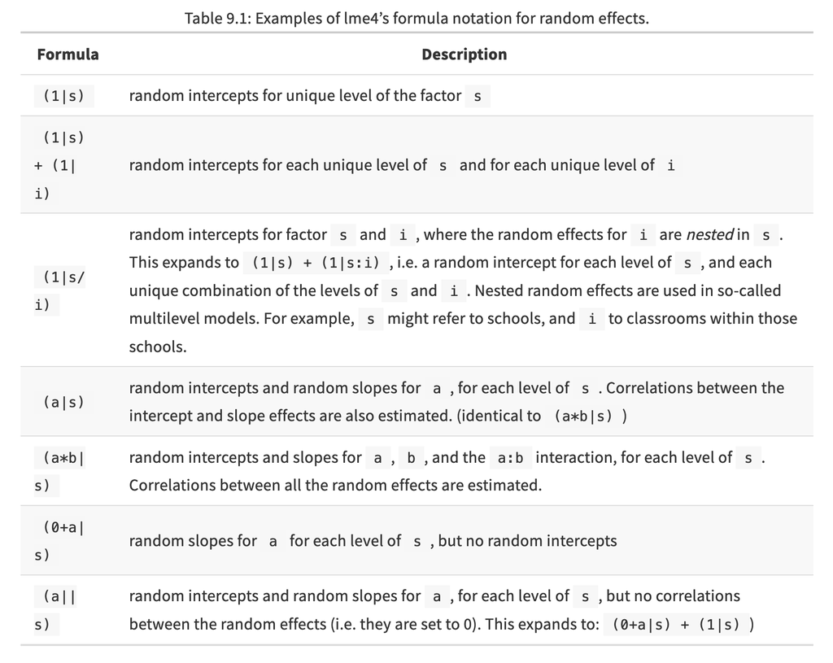

.

[Learn from others’ mistakes](https://retractionwatch.com/2016/02/03/makeup-use-linked-to-testosterone-levels-not-so-fast-says-retraction/)